# Funções do R para teste de hipóteses III

Mauro Campos

15 de maio de 2023

**Referências** para leitura deste material:

- P. Morettin & W. Bussab. Estatística Básica. 6a ed. São Paulo: Saraiva, 2010.
- M. Magalhães & AC. Lima. Noções de Probabolidade e Estatística Básica. 5a ed. São Paulo: EDUSP, 2002.
- M. Campos. Introdução ao R. Vitória, 2018. Disponível em: https://maurocmcampos.github.io/ec/html/intror.html.
- M. Campos. Funções do R para estatística descritiva. Vitória, 2023. Disponível em: https://maurocmcampos.github.io/ec/html/edR.html.
- M. Campos. Funções do R para teste de hipóteses I. Vitória, 2023. Disponível em: https://maurocmcampos.github.io/ec/html/th1R.html.

# 1 Testes qui-quadrado

## 1.1 Teste de aderência

**Problema**. Seja $X$ uma variável aleatória (va.a.) que representa o número de impactos anteriores a falha de um equipamento eletrônico. Uma amostra aleatória simples de 80 observações de $X$ foi obtida e os dados estão apresentados no script abaixo. Deseja-se realizar o seguinte teste:

$$\begin{cases}
H_{0}: & \mbox{$X$ segue o modelo geométrico com parâmetro $p=0.4$}
\\
H_{1}: & \mbox{$X$ segue outra distribuição.}
\end{cases}$$

A função `chisq.test()` pode ser usada para realizar este teste de aderência.

```r
df0 <- read.table(file="impactos.txt",header=TRUE)
str(df0)
```

```
## 'data.frame':    80 obs. of  1 variable:
##  $ x: int  0 1 0 1 0 0 1 1 0 0 ...
```

```r
#
# Dados
#
df0$x
```

```
##  [1] 0 1 0 1 0 0 1 1 0 0 1 1 0 0 5 1 0 1 5 1 7 1 0 2 3 1 6 4 0 3 0 2 0 0 2 0 3 0
## [39] 1 0 2 1 1 1 1 2 1 4 4 0 0 4 1 0 4 3 0 2 0 0 1 2 0 1 1 0 0 0 1 1 1 2 0 2 1 2
## [77] 1 0 0 3
```

```r
table(df0$x)
```

```
##
##  0  1  2  3  4  5  6  7
## 30 26 10  5  5  2  1  1
```

```r
classes <- names(table(df0$x))
freq <- as.vector(table(df0$x))
freq.r <- round(100*as.vector(prop.table(freq)),2)
freq.a <- cumsum(freq.r)
df <- data.frame(classe=c(classes,"Total"),
                 frequencia.absoluta=c(freq,sum(freq)),
                 freq.relativa=c(freq.r,sum(freq.r)),
                 freq.acumulada=c(freq.a,NaN))
df
```

```
##   classe frequencia.absoluta freq.relativa freq.acumulada
## 1      0                  30         37.50          37.50
## 2      1                  26         32.50          70.00
## 3      2                  10         12.50          82.50
## 4      3                   5          6.25          88.75
## 5      4                   5          6.25          95.00
## 6      5                   2          2.50          97.50
## 7      6                   1          1.25          98.75
## 8      7                   1          1.25         100.00
## 9  Total                  80        100.00            NaN
```

```r
freq.o <- df$frequencia.absoluta[-dim(df)[1]]
vec.p <- c(dgeom(0:6,prob=0.4),pgeom(6,prob=0.4,lower.tail=FALSE))
freq.e <- sum(freq.o)*vec.p
data.frame(classe=c("0","1","2","3","4","5","6",">6"),freq.o,freq.e,vec.p)
```

```
##   classe freq.o    freq.e     vec.p
## 1      0     30 32.000000 0.4000000
## 2      1     26 19.200000 0.2400000
## 3      2     10 11.520000 0.1440000
## 4      3      5  6.912000 0.0864000
## 5      4      5  4.147200 0.0518400
## 6      5      2  2.488320 0.0311040
## 7      6      1  1.492992 0.0186624
## 8     >6      1  2.239488 0.0279936
```

```r
ni <- c(freq.o[1:4],sum(freq.o[5:8]));n <- sum(ni)
prob <- c(dgeom(0:3,prob=0.4),pgeom(3,prob=0.4,lower.tail=FALSE))
data.frame(i=1:5,ni,npi=n*prob,prob)
```

```
##   i ni    npi   prob
## 1 1 30 32.000 0.4000
## 2 2 26 19.200 0.2400
## 3 3 10 11.520 0.1440
## 4 4  5  6.912 0.0864
## 5 5  9 10.368 0.1296
```

```r
out <- chisq.test(x=ni,p=prob);out
```

```
##
##  Chi-squared test for given probabilities
##
## data:  ni
## X-squared = 3.4433, df = 4, p-value = 0.4866
```

```r
names(out)
```

```
## [1] "statistic" "parameter" "p.value"   "method"    "data.name" "observed"
## [7] "expected"  "residuals" "stdres"
```

```r
out$statistic
## X-squared
##  3.443287
out$parameter
## df
##  4
out$p.value
```

```
## [1] 0.4865539
```

```r
out$method
```

```
## [1] "Chi-squared test for given probabilities"
```

```r
out$data.name
```

```
## [1] "ni"
```

```r
out$observed
```

```
## [1] 30 26 10  5  9
```

```r
out$expected
```

```
## [1] 32.000 19.200 11.520  6.912 10.368
```

```r
q <- qchisq(p=0.05,df=out$parameter,lower.tail=FALSE);q
```

```
## [1] 9.487729
```

Não rejeitamos $H_{0}$, ou seja, existem evidências experimentais que $X$ segue o modelo geométrico com $p=0.4$.

**Problema**. Seja $X$ uma va.a. que representa a porcentagem de cinzas contidas no carvão produzido por uma certa empresa. Uma amostra aleatória simples de 250 observações de $X$ foi obtida e os dados estão apresentados no script abaixo. Deseja-se realizar o seguinte teste:

$$\begin{cases}
H_{0}: & \mbox{$X$ segue o modelo normal} \\
H_{1}: & \mbox{$X$ segue outra distribuição.}
\end{cases}$$

```r
df0 <- read.table(file="cinzas.txt",header=TRUE)
str(df0)
```

```
## 'data.frame':    250 obs. of  1 variable:
##  $ x: num  13 14.6 15.5 15 13.4 ...
```

```r
#
# Dados
#
head(df0)
```

```
##        x
## 1 13.029
## 2 14.553
## 3 15.548
## 4 15.010
## 5 13.390
## 6 16.161
```

```r
tail(df0)
```

```
##          x
## 245 15.252
## 246 15.402
## 247 13.278
## 248 11.789
## 249 12.788
## 250 12.015
```

```r
xd <- cut(df0$x,breaks=seq(9.5,19.5,1),right=FALSE)
table(xd)
## xd
##  [9.5,10.5) [10.5,11.5) [11.5,12.5) [12.5,13.5) [13.5,14.5) [14.5,15.5)
##           2           5          16          42          69          51
## [15.5,16.5) [16.5,17.5) [17.5,18.5) [18.5,19.5)
##          32          23           9           1
classes <- names(table(xd))
freq <- as.vector(table(xd))
freq.r <- round(100*as.vector(prop.table(freq)),2)
freq.a <- cumsum(freq.r)
df <- data.frame(classe=c(classes,"Total"),
                 frequencia.absoluta=c(freq,sum(freq)),
                 freq.relativa=c(freq.r,sum(freq.r)),
                 freq.acumulada=c(freq.a,NaN))
df
```

```
##         classe frequencia.absoluta freq.relativa freq.acumulada
## 1   [9.5,10.5)                   2           0.8            0.8
## 2  [10.5,11.5)                   5           2.0            2.8
## 3  [11.5,12.5)                  16           6.4            9.2
## 4  [12.5,13.5)                  42          16.8           26.0
## 5  [13.5,14.5)                  69          27.6           53.6
## 6  [14.5,15.5)                  51          20.4           74.0
## 7  [15.5,16.5)                  32          12.8           86.8
## 8  [16.5,17.5)                  23           9.2           96.0
## 9  [17.5,18.5)                   9           3.6           99.6
## 10 [18.5,19.5)                   1           0.4          100.0
## 11       Total                 250         100.0            NaN
```

```r
dim(df)
```

```
## [1] 11  4
```

```r
freq.o <- df$frequencia.absoluta[-dim(df)[1]]
aux <- seq(10,19,1)
x.bar <- sum(freq.o*aux)/sum(freq.o);x.bar
```

```
## [1] 14.512
```

```r
s2 <- sum(freq.o*(aux-x.bar)^(2))/(sum(freq.o)-1)
s <- sqrt(s2);s
```

```
## [1] 1.643368
```

```r
vec.p <- NULL
r <- length(aux)
for(k in 1:r){
  if(k==1){vec.p[k] <- pnorm(aux[k]+0.5,x.bar,s)}
  if((k>1)&(k<r)){vec.p[k] <- pnorm(aux[k]+0.5,x.bar,s)-pnorm(aux[k]-0.5,x.bar,s)}
  if(k==r){vec.p[k] <- 1-sum(vec.p[1:(k-1)])}
}
freq.e <- sum(freq.o)*vec.p
data.frame(classe=classes,freq.o,freq.e,vec.p)
```

```
##         classe freq.o    freq.e       vec.p
## 1   [9.5,10.5)      2  1.829171 0.007316685
## 2  [10.5,11.5)      5  6.524473 0.026097891
## 3  [11.5,12.5)     16 19.250539 0.077002156
## 4  [12.5,13.5)     42 39.648433 0.158593733
## 5  [13.5,14.5)     69 57.019114 0.228076454
## 6  [14.5,15.5)     51 57.265283 0.229061130
## 7  [15.5,16.5)     32 40.164249 0.160656996
## 8  [16.5,17.5)     23 19.669870 0.078679479
## 9  [17.5,18.5)      9  6.724386 0.026897545
## 10 [18.5,19.5)      1  1.904483 0.007617930
```

```r
ni <- c(sum(freq.o[1:2]),freq.o[3:8],sum(freq.o[9:10]));n <- sum(ni)
prob <- c(sum(vec.p[1:2]),vec.p[3:8],sum(vec.p[9:10]))
data.frame(i=1:8,ni,npi=n*prob,prob)
```

```
##   i ni       npi       prob
## 1 1  7  8.353644 0.03341458
## 2 2 16 19.250539 0.07700216
## 3 3 42 39.648433 0.15859373
## 4 4 69 57.019114 0.22807645
## 5 5 51 57.265283 0.22906113
## 6 6 32 40.164249 0.16065700
## 7 7 23 19.669870 0.07867948
## 8 8 10  8.628869 0.03451548
```

```r
out <- chisq.test(x=ni,p=prob)
out
```

```
##
##  Chi-squared test for given probabilities
##
## data:  ni
## X-squared = 6.5518, df = 7, p-value = 0.477
```

```r
out$observed
```

```
## [1]  7 16 42 69 51 32 23 10
```

```r
out$expected
```

```
## [1]  8.353644 19.250539 39.648433 57.019114 57.265283 40.164249 19.669870
## [8]  8.628869
```

```r
pvalor <- as.numeric(pchisq(q=out$statistic,df=out$parameter,lower.tail=FALSE))
pvalor
```

```
## [1] 0.4769844
```

```r
q <- qchisq(p=0.05,df=out$parameter,lower.tail=FALSE);q
```

```
## [1] 14.06714
```

```r
pvalor.corrigido <- as.numeric(pchisq(q=out$statistic,df=out$parameter-2,lower.tail=FALSE))
pvalor.corrigido
```

```
## [1] 0.2561615
```

```r
q <- qchisq(p=0.05,df=out$parameter-2,lower.tail=FALSE);q
```

```
## [1] 11.0705
```

Não rejeitamos $H_{0}$, ou seja, existem evidências experimentais que $X$ segue o modelo normal com $\mu=14.5$ e $\sigma^{2}=2.7$.

## 1.2 Teste de homogeneidade

**Problema**. Estamos interessados em saber se a preferência por certo tipo de filme se altera em função do estado civil. Selecionou-se 100 indivíduos em cada uma das seguintes categorias: solteiro, casado, divorciado e viúvo. Para cada categoria levantou-se a preferência dos 100 indivíduos em relação aos seguintes tipos de filmes, a saber: policial, comédia e romance. Os resultados estão apresentados no seguinte script. Se $X$ é uma variável categórica representando o estado civil do indivíduo e $Y$ é outra variável categórica representando sua preferência por tipo de filme deseja-se verificar se a distribuição condicional da preferência por tipo de filme dado o estado civil é homogênea com respeito às diferentes categorias de estado civil. Ou seja, deseja-se realizar o seguinte teste:

$$\begin{cases}
H_{0}: & \mbox{A distribuição de $Y$ dado $[X=x]$ é homogênea com
respeito a $x$} \\
H_{1}: & \mbox{A distribuição de $Y$ dado $[X=x]$ não é homogênea
com respeito a $x$.}
\end{cases}$$

A função `chisq.test()` pode ser usada para realizar este teste de homogeneidade.

```r
df <- read.table(file="filmes.txt",header=TRUE,stringsAsFactors=FALSE)
df$x <- factor(df$x,levels=c("Solteiro","Casado","Divorciado","viuvo"))
df$y <- factor(df$y,levels=c("Policial","Comedia","Romance"))
str(df)
```

```
## 'data.frame':    400 obs. of  2 variables:
##  $ x: Factor w/ 4 levels "Solteiro","Casado",..: 1 1 1 1 1 1 1 1 1 1 ...
##  $ y: Factor w/ 3 levels "Policial","Comedia",..: 1 3 2 2 1 1 3 3 1 1 ...
```

```r
#
# Dados
#
head(df)
```

```
##          x        y
## 1 Solteiro Policial
## 2 Solteiro  Romance
## 3 Solteiro  Comedia
## 4 Solteiro  Comedia
## 5 Solteiro Policial
## 6 Solteiro Policial
```

```r
tail(df)
```

```
##         x        y
## 395 viuvo  Comedia
## 396 viuvo Policial
## 397 viuvo  Romance
## 398 viuvo Policial
## 399 viuvo  Comedia
## 400 viuvo  Comedia
```

```r
tab <- table(df)
addmargins(tab)
```

```
##             y
## x            Policial Comedia Romance Sum
##   Solteiro         45      25      30 100
##   Casado           26      41      33 100
##   Divorciado       36      33      31 100
##   viuvo            28      38      34 100
##   Sum             135     137     128 400
```

```r
out <- chisq.test(x=tab);out
```

```
##
##  Pearson's Chi-squared test
##
## data:  tab
## X-squared = 11.256, df = 6, p-value = 0.08077
```

```r
names(out)
```

```
## [1] "statistic" "parameter" "p.value"   "method"    "data.name" "observed"
## [7] "expected"  "residuals" "stdres"
```

```r
out$statistic
## X-squared
##  11.25643
out$parameter
## df
##  6
out$p.value
```

```
## [1] 0.08076717
```

```r
out$method
```

```
## [1] "Pearson's Chi-squared test"
```

```r
out$data.name
```

```
## [1] "tab"
```

```r
out$observed
```

```
##             y
## x            Policial Comedia Romance
##   Solteiro         45      25      30
##   Casado           26      41      33
##   Divorciado       36      33      31
##   viuvo            28      38      34
```

```r
out$expected
```

```
##             y
## x            Policial Comedia Romance
##   Solteiro      33.75   34.25      32
##   Casado        33.75   34.25      32
##   Divorciado    33.75   34.25      32
##   viuvo         33.75   34.25      32
```

```r
q <- qchisq(p=0.05,df=out$parameter,lower.tail=FALSE);q
```

```
## [1] 12.59159
```

Não rejeitamos $H_{0}$, ou seja, a preferência pelo tipo de filme é a mesma, não importando o estado civil.

```r
#
# Visualização dos dados
#
round(100*prop.table(tab,1),1)
```

```
##             y
## x            Policial Comedia Romance
##   Solteiro         45      25      30
##   Casado           26      41      33
##   Divorciado       36      33      31
##   viuvo            28      38      34
```

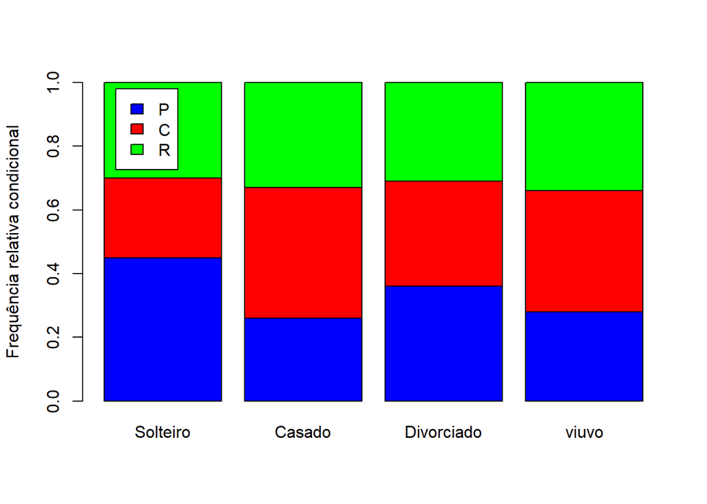

```r
cores <- c("blue","red","green")
legenda <- c("P","C","R")
barplot(t(prop.table(tab,1)),col=cores,ylab="Frequência relativa condicional",ylim=c(0,1))
legend(0.30,0.98,legend=legenda,fill=cores)
```

```r
dev.off()
## null device
##           1
```

**Problema**. Em aparelhos dentários são usados grampos de dois tipos: um modelo em T e outro circunferencial C. Deseja-se verificar se a resistência à remoção de grampos do tipo T é a mesma dos grampos do tipo C. Foram usados 40 corpos de provas (dente-grampo), sendo 20 corpos (selecionados aleatoriamente) destinados para o tipo T e os outros 20 corpos restantes destinados para o tipo C, com 5 leituras de resistência à remoção para cada corpo de prova, totalizando 100 observações para cada tipo de grampo. O grupo de controle é aquele constituído pelos grampos do tipo T e o tratamento é aquele constituído pelos grampos do tipo C. Se $X$ é uma variável categórica representando o tipo de grampo e $Y$ é uma variável numérica representando a resistência à remoção do grampo (medida em kg), deseja-se verificar se a distribuição condicional da resistência à remoção do grampo dado seu tipo é homogênea com respeito aos dois tipo de grampo estudados. Ou seja, deseja-se realizar o seguinte teste:

$$\begin{cases}
H_{0}: & \mbox{A distribuição de $Y$ dado $[X=x]$ é homogênea com
respeito a $x$} \\
H_{1}: & \mbox{A distribuição de $Y$ dado $[X=x]$ não é homogênea
com respeito a $x$.}
\end{cases}$$

```r
df <- read.table(file="grampos.txt",header=TRUE,stringsAsFactors=FALSE)
df$x <- factor(df$x,levels=c("T","C"))
yd <- cut(df$y,breaks=seq(0.4,2.8,0.6),right=FALSE)
classes <- levels(yd);classes
```

```
## [1] "[0.4,1)"   "[1,1.6)"   "[1.6,2.2)" "[2.2,2.8)"
```

```r
df$yd <- yd
class(df)
```

```
## [1] "data.frame"
```

```r
str(df)
```

```
## 'data.frame':    200 obs. of  3 variables:
##  $ x : Factor w/ 2 levels "T","C": 1 1 1 1 1 1 1 1 1 1 ...
##  $ y : num  0.672 0.714 1.262 1.56 0.877 ...
##  $ yd: Factor w/ 4 levels "[0.4,1)","[1,1.6)",..: 1 1 2 2 1 2 2 2 2 1 ...
```

```r
#
# Dados
#
head(df)
```

```
##   x      y      yd
## 1 T 0.6716 [0.4,1)
## 2 T 0.7144 [0.4,1)
## 3 T 1.2622 [1,1.6)
## 4 T 1.5595 [1,1.6)
## 5 T 0.8769 [0.4,1)
## 6 T 1.0647 [1,1.6)
```

```r
tail(df)
```

```
##     x      y        yd
## 195 C 1.0157   [1,1.6)
## 196 C 1.5322   [1,1.6)
## 197 C 0.8795   [0.4,1)
## 198 C 1.1393   [1,1.6)
## 199 C 1.9992 [1.6,2.2)
## 200 C 0.8686   [0.4,1)
```

```r
tab <- table(df[,c(1,3)])
colnames(tab) <- c("Baixa","Moderada","Alta","Extra-alta")
dimnames(tab) <- list(Grampo=c("T","C"),Resistencia=c("Baixa","Moderada","Alta","Extra-alta"))
tab
```

```
##       Resistencia
## Grampo Baixa Moderada Alta Extra-alta
##      T    29       60    9          2
##      C    37       44   13          6
```

```r
addmargins(tab)
```

```
##       Resistencia
## Grampo Baixa Moderada Alta Extra-alta Sum
##    T      29       60    9          2 100
##    C      37       44   13          6 100
##    Sum    66      104   22          8 200
```

```r
out <- chisq.test(tab)
out
```

```
##
##  Pearson's Chi-squared test
##
## data:  tab
## X-squared = 6.1585, df = 3, p-value = 0.1041
```

```r
out$observed
```

```
##       Resistencia
## Grampo Baixa Moderada Alta Extra-alta
##      T    29       60    9          2
##      C    37       44   13          6
```

```r
out$expected
```

```
##       Resistencia
## Grampo Baixa Moderada Alta Extra-alta
##      T    33       52   11          4
##      C    33       52   11          4
```

```r
q <- qchisq(p=0.05,df=out$parameter,lower.tail=FALSE);q
```

```
## [1] 7.814728
```

É importante ressaltar duas observações:

- Solicitar que o p-valor do teste seja calculado via sumulação Monte Carlo.
- Agregar categorias para que todas as frequências esperadas sejam maiores do que 5.

```r
#
# Opção 1
#
chisq.test(tab,simulate.p.value=TRUE,B=2000)
```

```
##
##  Pearson's Chi-squared test with simulated p-value (based on 2000
##  replicates)
##
## data:  tab
## X-squared = 6.1585, df = NA, p-value = 0.1059
```

```r
#
# Opção 2
#
# As categorias A e EA foram agregadas e renomeadas em conjunto por A (Alta)
#
tab.modificada <- matrix(c(29,60,11,37,44,19),nrow=2,ncol=3,byrow=TRUE)
rownames(tab.modificada) <- c("T","C")
colnames(tab.modificada) <- c("Baixa","Moderada","Alta")
dimnames(tab.modificada) <- list(Grampo=c("T","C"),Resistencia=c("Baixa","Moderada","Alta"))
tab.modificada
```

```
##       Resistencia
## Grampo Baixa Moderada Alta
##      T    29       60   11
##      C    37       44   19
```

```r
out <- chisq.test(x=tab.modificada);out
```

```
##
##  Pearson's Chi-squared test
##
## data:  tab.modificada
## X-squared = 5.5646, df = 2, p-value = 0.0619
```

```r
out$observed
```

```
##       Resistencia
## Grampo Baixa Moderada Alta
##      T    29       60   11
##      C    37       44   19
```

```r
out$expected
```

```
##       Resistencia
## Grampo Baixa Moderada Alta
##      T    33       52   15
##      C    33       52   15
```

```r
q <- qchisq(p=0.05,df=out$parameter,lower.tail=FALSE);q
```

```
## [1] 5.991465
```

Após implementar as duas opções propostas, a decisão do teste não se alterou. Não rejeitamos $H_{0}$, ou seja, a distribuição da resistência à remoção do grampo é a mesma, não importando o tipo do grampo.

```r
#
# Visualização dos dados
#
round(100*prop.table(tab,1),1)
```

```
##       Resistencia
## Grampo Baixa Moderada Alta Extra-alta
##      T    29       60    9          2
##      C    37       44   13          6
```

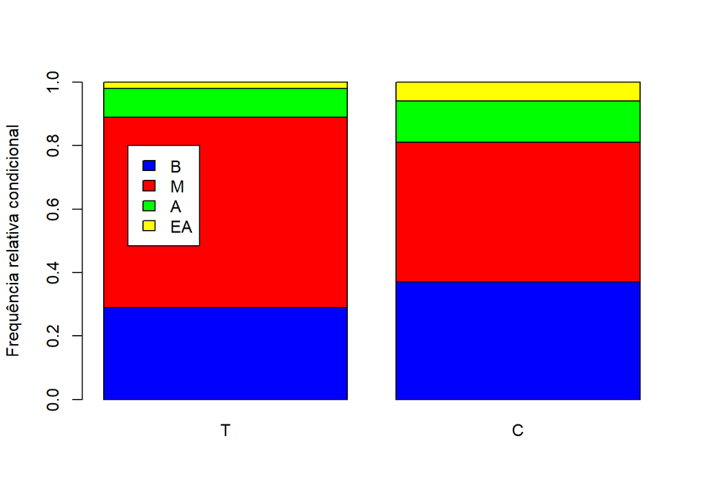

```r
cores <- c("blue","red","green","yellow")
legenda <- c("B","M","A","EA")
barplot(t(prop.table(tab,1)),col=cores,ylab="Frequência relativa condicional",ylim=c(0,1))
legend(0.30,0.80,legend=legenda,fill=cores)
```

```r
dev.off()
## null device
##           1
```

## 1.3 Teste de independência

**Problema**. Um exame com questões das disciplinas física e matemática foi aplicado a 528 estudantes do ensino médio. As notas obtidas por cada estudante em física e matemática foram registradas e classificadas nas seguintes categorias: alta, média e baixa. Os dados estão apresentados no script abaixo. Se $X$ e $Y$ são variáveis categóricas descrevendo as notas em física e matemática, deseja-se testar se existe dependência entre as notas dessas duas disciplinas. Ou seja, deseja-se realizar o seguinte teste:

$$\begin{cases}
H_{0}: & \mbox{$X$ e $Y$ são independentes} \\
H_{1}: & \mbox{$X$ e $Y$ não são independentes.}
\end{cases}$$

A função `chisq.test()` pode ser usada para realizar este teste de independência.

```r
df <- read.table(file="notas.txt",header=TRUE,stringsAsFactors=FALSE)
df$x <- factor(df$x,levels=c("alta","media","baixa"))
df$y <- factor(df$y,levels=c("alta","media","baixa"))
str(df)
```

```
## 'data.frame':    528 obs. of  2 variables:
##  $ x: Factor w/ 3 levels "alta","media",..: 3 1 1 2 3 2 2 3 1 2 ...
##  $ y: Factor w/ 3 levels "alta","media",..: 3 1 2 1 1 1 2 3 2 2 ...
```

```r
head(df)
```

```
##         x     y
## 528 baixa baixa
## 37   alta  alta
## 116  alta media
## 170 media  alta
## 389 baixa  alta
## 178 media  alta
```

```r
tail(df)
```

```
##         x     y
## 351 media baixa
## 488 baixa baixa
## 155 media  alta
## 95   alta media
## 297 media media
## 174 media  alta
```

```r
#
# Dados
#
tab <- table(df)
tab
```

```
##        y
## x       alta media baixa
##   alta    56    71    12
##   media   47   163    38
##   baixa   14    42    85
```

```r
addmargins(tab)
```

```
##        y
## x       alta media baixa Sum
##   alta    56    71    12 139
##   media   47   163    38 248
##   baixa   14    42    85 141
##   Sum    117   276   135 528
```

```r
freq <- prop.table(tab);100*round(freq,4)
```

```
##        y
## x        alta media baixa
##   alta  10.61 13.45  2.27
##   media  8.90 30.87  7.20
##   baixa  2.65  7.95 16.10
```

```r
out <- chisq.test(x=tab);out
```

```
##
##  Pearson's Chi-squared test
##
## data:  tab
## X-squared = 145.78, df = 4, p-value < 2.2e-16
```

```r
pvalor.exato <- pchisq(q=out$statistic,df=out$parameter,lower.tail=FALSE)
pvalor.exato
```

```
##    X-squared
## 1.631603e-30
```

Rejeitamos $H_{0}$, ou seja, as notas de física e matemática não são independentes.

# 2 Outros testes de aderência

## 2.1 Teste de Kolmogorov-Smirnov

**Problema**. Considere os dados abaixo (veja o script), que supomos ser uma amostra de tamanho 30 de uma normal com média 10 e variância 25. Desejamos testar esta afirmação.

```r
dados <- c(1.04,1.73,3.93,4.44,6.37,6.51,
           7.61,7.64,8.18,8.48,8.57,8.65,
           9.71,9.87,9.95,10.01,10.52,10.69,
           11.72,12.17,12.61,12.98,13.03,13.16,
           14.11,14.60,14.64,14.75,16.68,22.14)
summary(dados)
```

```
##    Min. 1st Qu.  Median    Mean 3rd Qu.    Max.
##   1.040   7.775   9.980  10.216  13.018  22.140
```

```r
var(dados)
```

```
## [1] 19.9545
```

```r
sd(dados)
```

```
## [1] 4.467046
```

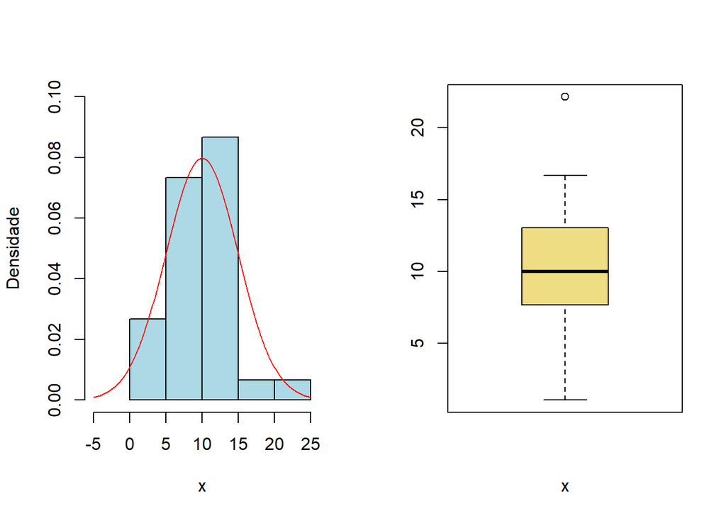

```r
par(mfrow=c(1,2))
hist(dados,breaks=seq(0,25,5),freq=FALSE,right=FALSE,
     xlim=c(-5,25),ylim=c(0,0.1),col="lightblue",
     xlab="x",ylab="Densidade",main="")
curve(dnorm(x,mean=10,sd=5),-5,25,col="red",add=TRUE)
boxplot(dados,xlab="x",col="lightgoldenrod")
```

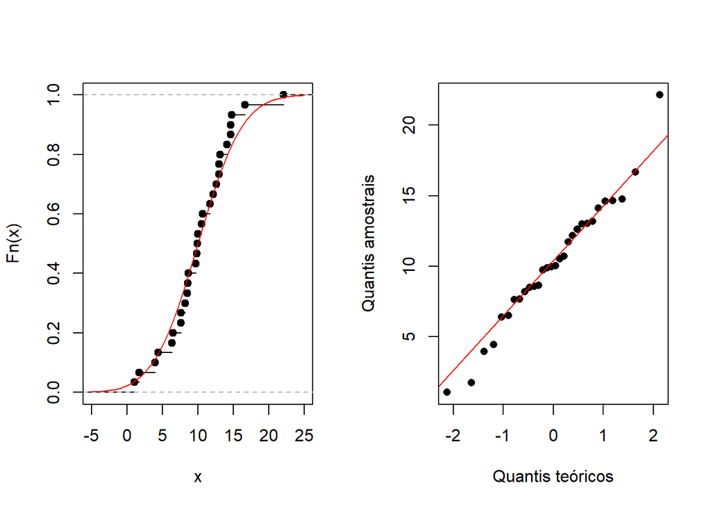

```r
par(mfrow=c(1,2))
plot(ecdf(dados),xlim=c(-5,25),main="")
curve(pnorm(x,mean=10,sd=5),-5,25,col="red",add=TRUE)
qqnorm(dados,type="p",pch=16,main="",xlab="Quantis teóricos",ylab="Quantis amostrais")
qqline(dados,probs=c(0.25,0.75),col="red")
```

```r
dev.off()
## null device
##           1
```

```r
dados
```

```
##  [1]  1.04  1.73  3.93  4.44  6.37  6.51  7.61  7.64  8.18  8.48  8.57  8.65
## [13]  9.71  9.87  9.95 10.01 10.52 10.69 11.72 12.17 12.61 12.98 13.03 13.16
## [25] 14.11 14.60 14.64 14.75 16.68 22.14
```

```r
out <- ks.test(x=dados,y="pnorm",mean=10,sd=5)
out
```

```
##
##  One-sample Kolmogorov-Smirnov test
##
## data:  dados
## D = 0.11633, p-value = 0.769
## alternative hypothesis: two-sided
```

```r
names(out)
```

```
## [1] "statistic"   "p.value"     "alternative" "method"      "data.name"
```

## 2.2 Teste de Shapiro-Wilk para normalidade

**Problema**. Considere novamente os dados abaixo (veja o script), que supomos ser uma amostra de tamanho 30 de uma normal com média 10 e variância 25. Desejamos testar esta afirmação de normalidade para os dados.

```r
dados <- c(1.04,1.73,3.93,4.44,6.37,6.51,
           7.61,7.64,8.18,8.48,8.57,8.65,
           9.71,9.87,9.95,10.01,10.52,10.69,
           11.72,12.17,12.61,12.98,13.03,13.16,
           14.11,14.60,14.64,14.75,16.68,22.14)
dados
```

```
##  [1]  1.04  1.73  3.93  4.44  6.37  6.51  7.61  7.64  8.18  8.48  8.57  8.65
## [13]  9.71  9.87  9.95 10.01 10.52 10.69 11.72 12.17 12.61 12.98 13.03 13.16
## [25] 14.11 14.60 14.64 14.75 16.68 22.14
```

```r
summary(dados)
```

```
##    Min. 1st Qu.  Median    Mean 3rd Qu.    Max.
##   1.040   7.775   9.980  10.216  13.018  22.140
```

```r
var(dados)
```

```
## [1] 19.9545
```

```r
sd(dados)
```

```
## [1] 4.467046
```

```r
out <- shapiro.test(x=dados)
out
```

```
##
##  Shapiro-Wilk normality test
##
## data:  dados
## W = 0.97813, p-value = 0.7739
```

```r
names(out)
```

```
## [1] "statistic" "p.value"   "method"    "data.name"
```

**Problema**. O gerente de um restaurante está interessado na distribuição do tempo de entrega de pedidos realizados pelo aplicativo do restaurante. Para tal estudo, uma amostra aleatória simples de 32 tempos de entrega (em minutos) foram registrados (veja os dados no script abaixo). Teste a hipótese de que esses tempos formam uma amostra aleatória simples de uma distribuição normal. Posteriormente, teste a hipótese que o tempo médio de entrega de pedidos pelo aplicativo é igual a 20 minutos versus a hipótese que esse tempo médio é diferente de 20 minutos. Por fim, proporcione uma estimativa intervalar com 95% de confiança para o tempo médio de entrega de pedidos pelo aplicativo.

```r
tempos <- c(4.24,9.94,11.31,11.84,13.89,19.97,21.18,22.15,
           22.44,24.69,25.20,25.36,25.62,26.96,27.25,27.42,
           29.98,32.54,32.98,34.88,35.34,35.44,35.57,36.29,
           37.03,38.13,41.88,44.16,48.89,49.78,51.63,52.27)
tempos
```

```
##  [1]  4.24  9.94 11.31 11.84 13.89 19.97 21.18 22.15 22.44 24.69 25.20 25.36
## [13] 25.62 26.96 27.25 27.42 29.98 32.54 32.98 34.88 35.34 35.44 35.57 36.29
## [25] 37.03 38.13 41.88 44.16 48.89 49.78 51.63 52.27
```

```r
summary(tempos)
```

```
##    Min. 1st Qu.  Median    Mean 3rd Qu.    Max.
##    4.24   22.37   28.70   29.88   36.48   52.27
```

```r
var(tempos)
```

```
## [1] 153.3435
```

```r
sd(tempos)
```

```
## [1] 12.38319
```

```r
tempos.d <- cut(tempos,breaks=seq(0,60,10),right=FALSE)
classes <- levels(tempos.d)
freq <- as.vector(table(tempos.d))
freq.r <- round(100*as.vector(prop.table(freq)),2)
freq.a <- cumsum(freq.r)
data.frame(classe=c(classes,"Total"),
           frequencia=c(freq,sum(freq)),
           freq.relativa=c(freq.r,sum(freq.r)),
           freq.acumulada=c(freq.a,NaN))
```

```
##    classe frequencia freq.relativa freq.acumulada
## 1  [0,10)          2          6.25           6.25
## 2 [10,20)          4         12.50          18.75
## 3 [20,30)         11         34.38          53.13
## 4 [30,40)          9         28.12          81.25
## 5 [40,50)          4         12.50          93.75
## 6 [50,60)          2          6.25         100.00
## 7   Total         32        100.00            NaN
```

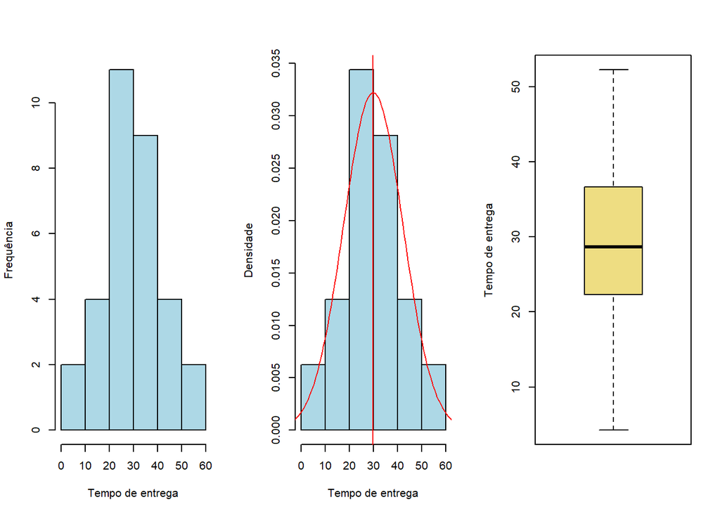

```r
par(mfrow=c(1,3))
hist(tempos,breaks=seq(0,60,10),freq=TRUE,right=FALSE,
     col="lightblue",xlab="Tempo de entrega",ylab="Frequência",main="")
hist(tempos,breaks=seq(0,60,10),freq=FALSE,right=FALSE,
     col="lightblue",xlab="Tempo de entrega",ylab="Densidade",main="")
curve(dnorm(x,mean=mean(tempos),sd=sd(tempos)),-10,70,col="red",add=TRUE)
abline(v=mean(tempos),col="red")
boxplot(tempos,ylab="Tempo de entrega",col="lightgoldenrod")
```

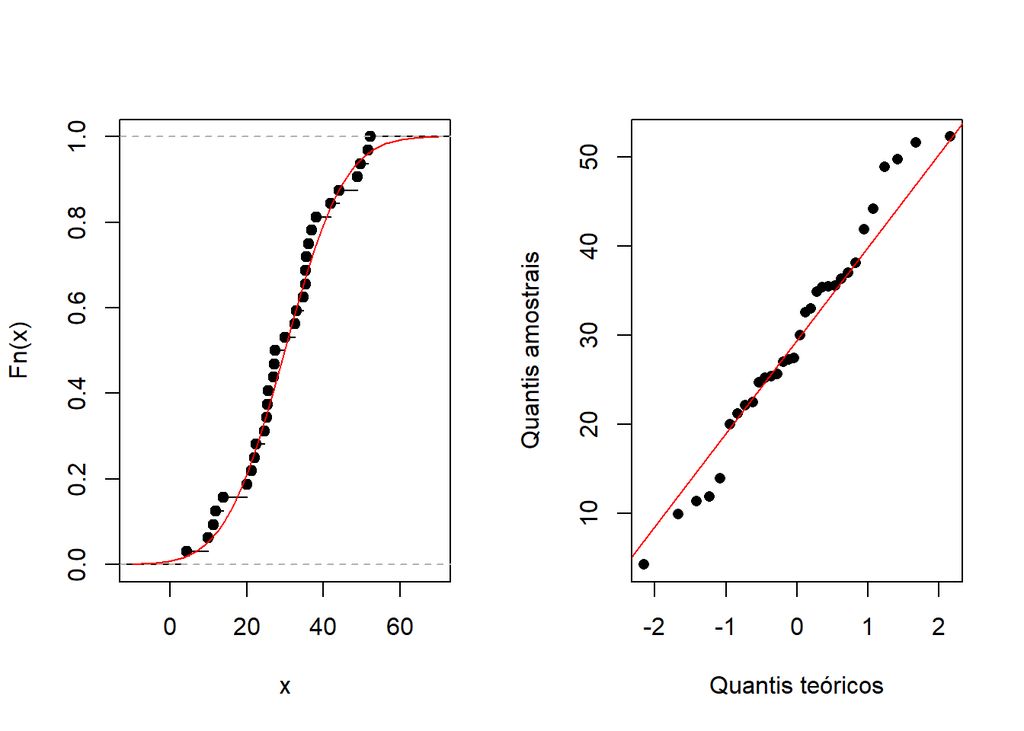

```r
par(mfrow=c(1,2))
plot(ecdf(tempos),xlim=c(-10,70),main="")
curve(pnorm(x,mean(tempos),sd=sd(tempos)),-10,70,col="red",add=TRUE)
qqnorm(tempos,type="p",pch=16,main="",xlab="Quantis teóricos",ylab="Quantis amostrais")
qqline(tempos,probs=c(0.25,0.75),col="red")
```

```r
dev.off()
## null device
##           1
```

```r
#
# Testes de hipóteses
#
tempos
```

```
##  [1]  4.24  9.94 11.31 11.84 13.89 19.97 21.18 22.15 22.44 24.69 25.20 25.36
## [13] 25.62 26.96 27.25 27.42 29.98 32.54 32.98 34.88 35.34 35.44 35.57 36.29
## [25] 37.03 38.13 41.88 44.16 48.89 49.78 51.63 52.27
```

```r
out1 <- shapiro.test(x=tempos) # teste de normalidade
out1
```

```
##
##  Shapiro-Wilk normality test
##
## data:  tempos
## W = 0.97573, p-value = 0.6696
```

```r
out2 <- t.test(x=tempos,mu=20,alternative="two.sided",conf.level=0.95)
out2
```

```
##
##  One Sample t-test
##
## data:  tempos
## t = 4.5146, df = 31, p-value = 8.588e-05
## alternative hypothesis: true mean is not equal to 20
## 95 percent confidence interval:
##  25.41819 34.34743
## sample estimates:
## mean of x
##  29.88281
```

```r
#
# Estimativa intervalar
#
out2$conf.int
```

```
## [1] 25.41819 34.34743
## attr(,"conf.level")
## [1] 0.95
```

**Problema**. Um material radioativo emite partículas alfa ao longo do tempo. Deseja-se entender a distribuição dos tempos entre duas emissões sucessivas de partículas alfa deste material. Para tal estudo, uma amostra aleatória simples de 36 tempos entre duas emissões sucessivas foram registrados (veja os dados no script abaixo). Teste a hipótese que esses tempos aderem ao modelo normal.

```r
temp <- c(0.02,0.04,0.05,0.06,0.07,0.08,0.09,0.10,0.12,
          0.22,0.28,0.33,0.34,0.35,0.36,0.43,0.45,0.46,
          0.61,0.62,0.74,0.80,0.81,0.85,0.90,0.93,1.02,
          1.09,1.17,1.18,1.40,1.53,1.54,1.81,2.02,2.10)
summary(temp)
```

```
##    Min. 1st Qu.  Median    Mean 3rd Qu.    Max.
##  0.0200  0.1950  0.5350  0.6936  1.0375  2.1000
```

```r
var(temp)
```

```
## [1] 0.353178
```

```r
sd(temp)
```

```
## [1] 0.5942878
```

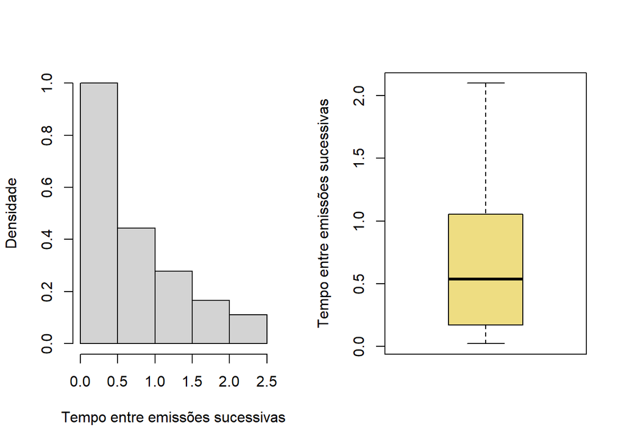

```r
#
# Visualização dos dados
#
par(mfrow=c(1,2))
hist(temp,breaks=seq(0.0,2.5,0.5),freq=FALSE,
     xlab="Tempo entre emissões sucessivas",
     ylab="Densidade",main="")
boxplot(temp,ylab="Tempo entre emissões sucessivas",
        col="lightgoldenrod")
```

```r
dev.off()
## null device
##           1
```

```r
dados
```

```
##  [1]  1.04  1.73  3.93  4.44  6.37  6.51  7.61  7.64  8.18  8.48  8.57  8.65
## [13]  9.71  9.87  9.95 10.01 10.52 10.69 11.72 12.17 12.61 12.98 13.03 13.16
## [25] 14.11 14.60 14.64 14.75 16.68 22.14
```

```r
shapiro.test(x=temp)
```

```
##
##  Shapiro-Wilk normality test
##
## data:  temp
## W = 0.90421, p-value = 0.004458
```

```r
#
# A hipótese de normalidade é rejeitada pelo
# teste de Shapiro-Wilk. Este resultado já
# era esperado a partir da visualização dos
# dados.
#
# A hipótese que os dados aderem ao modelo
# exponencial com taxa 1.45 é aceita pelo
# teste de Kolmogorov-Smirnov.
#
ks.test(x=temp,y="pexp",rate=1.45)
```

```
##
##  One-sample Kolmogorov-Smirnov test
##
## data:  temp
## D = 0.10318, p-value = 0.8008
## alternative hypothesis: two-sided
```

# 3 Equivalências entre testes para uma mesma situação

## 3.1 Teste qui-quadrado e o teste-z: testes para proporção

**Problema**. Uma amostra de 500 habitantes de uma cidade com idade igual ou superior a 16 anos foi selecionada para participar de uma pesquisa de opinião. Cada pessoa na amostra respondeu se concordava ou não com a solução proposta pela prefeitura da cidade para resolver um problema municipal que está prejudicando seriamente a população. As opções de resposta para a pergunta são: sim (se a pessoa é favorável a solução proposta) ou não (se a pessoa não é favorável a solução proposta). Das 500 pessoas ouvidas, 300 responderam sim e 200 responderam não. Com base nos dados, deseja-se testar se a proporção da população em questão (habitantes da cidade com idade igual ou superior a 16 anos) que é favorável a solução proposta pela prefeitura é igual a 1/2 ou é diferente de 1/2.

```r
n0 <- 200;n1 <- 300
n <- n0+n1
respostas <- c(rep("nao",n0),rep("sim",n1))
respostas <- factor(respostas,levels=c("nao","sim"))
df <- data.frame(Indivíduos=1:n,Resposta=respostas)
str(df)
```

```
## 'data.frame':    500 obs. of  2 variables:
##  $ Indivíduos: int  1 2 3 4 5 6 7 8 9 10 ...
##  $ Resposta  : Factor w/ 2 levels "nao","sim": 1 1 1 1 1 1 1 1 1 1 ...
```

```r
freq <- as.vector(table(df$Resposta))
prop <- as.vector(prop.table(table(df$Resposta)))
tabela <- data.frame(Classe=c("Não","Sim"),Frequencia=freq,Proporções=prop)
tabela
```

```
##   Classe Frequencia Proporções
## 1    Não        200        0.4
## 2    Sim        300        0.6
```

```r
prop.test(x=n1,n=n,p=0.5,alternative="two.sided",conf.level=0.95,correct=FALSE)
```

```
##
##  1-sample proportions test without continuity correction
##
## data:  n1 out of n, null probability 0.5
## X-squared = 20, df = 1, p-value = 7.744e-06
## alternative hypothesis: true p is not equal to 0.5
## 95 percent confidence interval:
##  0.5564541 0.6420210
## sample estimates:
##   p
## 0.6
```

```r
chisq.test(x=c(n0,n1),p=c(0.5,0.5),correct=FALSE)
```

```
##
##  Chi-squared test for given probabilities
##
## data:  c(n0, n1)
## X-squared = 20, df = 1, p-value = 7.744e-06
```

```r
#
# Note que z^(2)=X-squared do teste qui-quadrado
#
p.hat <- n1/n;p.hat
```

```
## [1] 0.6
```

```r
z <- (p.hat-0.5)/sqrt((0.5*(1-0.5))/n);z
```

```
## [1] 4.472136
```

```r
z^(2)
```

```
## [1] 20
```

## 3.2 Teste qui-quadrado e o teste-z: testes para comparação de proporções

**Problema**. Para o lançamento da nova embalagem do sabonete SEBO a divisão de criação estuda duas propostas, a saber: (A) amarela com letras vermelhas ou (B) preta com letras douradas. Eles acreditam que a proposta A chama a atenção em pelo menos 5% a mais do que a proposta B. Para verificar a validade de tal informação conduziu-se o seguinte experimento: em cada um de dois supermercados semelhantes foram colocados sabonetes com cada tipo de embalagem, e a clientes selecionados aleatoriamente foi perguntado se tinham notado o sabonete e que descrevessem qual a embalagem. Os resultados estão apresentados no script abaixo.

```r
tabela <- matrix(c(168,180,232,420),nrow=2,ncol=2,byrow=FALSE)
rownames(tabela) <- c("A","B")
colnames(tabela) <- c("Sim","Não")
dimnames(tabela) <- list(Proposta=c("A","B"),Percepeção=c("Sim","Não"))
tabela
```

```
##         Percepeção
## Proposta Sim Não
##        A 168 232
##        B 180 420
```

```r
addmargins(tabela)
```

```
##         Percepeção
## Proposta Sim Não  Sum
##      A   168 232  400
##      B   180 420  600
##      Sum 348 652 1000
```

```r
prop.test(x=tabela,alternative="two.sided",conf.level=0.95,correct=FALSE)
```

```
##
##  2-sample test for equality of proportions without continuity
##  correction
##
## data:  tabela
## X-squared = 15.232, df = 1, p-value = 9.51e-05
## alternative hypothesis: two.sided
## 95 percent confidence interval:
##  0.05930437 0.18069563
## sample estimates:
## prop 1 prop 2
##   0.42   0.30
```

```r
chisq.test(x=tabela,correct=FALSE)
```

```
##
##  Pearson's Chi-squared test
##
## data:  tabela
## X-squared = 15.232, df = 1, p-value = 9.51e-05
```

```r
p1.hat <- 168/400;p1.hat
```

```
## [1] 0.42
```

```r
p2.hat <- 180/600;p2.hat
```

```
## [1] 0.3
```

```r
p <- 348/1000;p
```

```
## [1] 0.348
```

```r
z <- (p1.hat-p2.hat)/sqrt((p*(1-p))*((1/400)+(1/600)));z
```

```
## [1] 3.902774
```

```r
z^(2)
```

```
## [1] 15.23165
```

```r
#
# Note que z^(2)=X-squared do teste qui-quadrado
# Resultado análogo vale mesmo quando se aplica
# a correção de continuidade.
#
prop.test(x=tabela,alternative="two.sided",conf.level=0.95,correct=TRUE)
```

```
##
##  2-sample test for equality of proportions with continuity correction
##
## data:  tabela
## X-squared = 14.707, df = 1, p-value = 0.0001256
## alternative hypothesis: two.sided
## 95 percent confidence interval:
##  0.05722104 0.18277896
## sample estimates:
## prop 1 prop 2
##   0.42   0.30
```

```r
chisq.test(x=tabela,correct=TRUE)
```

```
##
##  Pearson's Chi-squared test with Yates' continuity correction
##
## data:  tabela
## X-squared = 14.707, df = 1, p-value = 0.0001256
```